# GWAS IV: Mendelian Randomization

BIOS 770

Josh Weinstock, PhD

Assistant Professor, Department of Human Genetics, Emory University

## Learning objectives

1. Discuss the assumptions of Mendelian randomization (MR)
2. Discuss a few notable MR methods
3. Close with discussion on the MR literature broadly

## Inferring causal effects of $\color{darkgreen}{X}$ on $\color{darkorange}{Y}$

Consider two phenotypes, measured in humans:

1. $\color{darkgreen}{X}$, some “exposure”, e.g., low-density lipoprotein, C-reactive protein, etc.
2. $\color{darkorange}{Y}$, some “outcome”, e.g., ischemic heart disease, systolic blood pressure, etc.

## Inferring the causal effect of $\color{darkgreen}{X}$ on $\color{darkorange}{Y}$

We are interested in inferring the causal effect of $\color{darkgreen}{X}$ on $\color{darkorange}{Y}$. Perhaps ideally, we could randomly assign values to $\color{darkgreen}{X}$, i.e., $do(\color{darkgreen}{X} = x)$, and then measure how $\color{darkorange}{Y}$ changes as we change $do(\color{darkgreen}{X} = x)$.

This works (e.g, RCTs). But obviously, for numerous pairs of $(\color{darkgreen}{X}, \color{darkorange}{Y})$, RCT isn’t tractable.

## Transmission of alleles as a pseudo-RCT

Perhaps we can instead use natural variation, with the *right kind of randomness*, as a proxy for an RCT, a kind of “natural experiment.” Consider genetic inheritance:

1. In the autosomes, offspring randomly inherit one of mother’s two alleles, and one of the father’s two alleles.
2. These alleles are transmitted indepenently on one another (putting aside linkage disequilibrium for now)

Perhaps with these principles in mind, we can view each trait relevant variant as a kind of RCT.

## Genetic variation as a parallel to an RCT

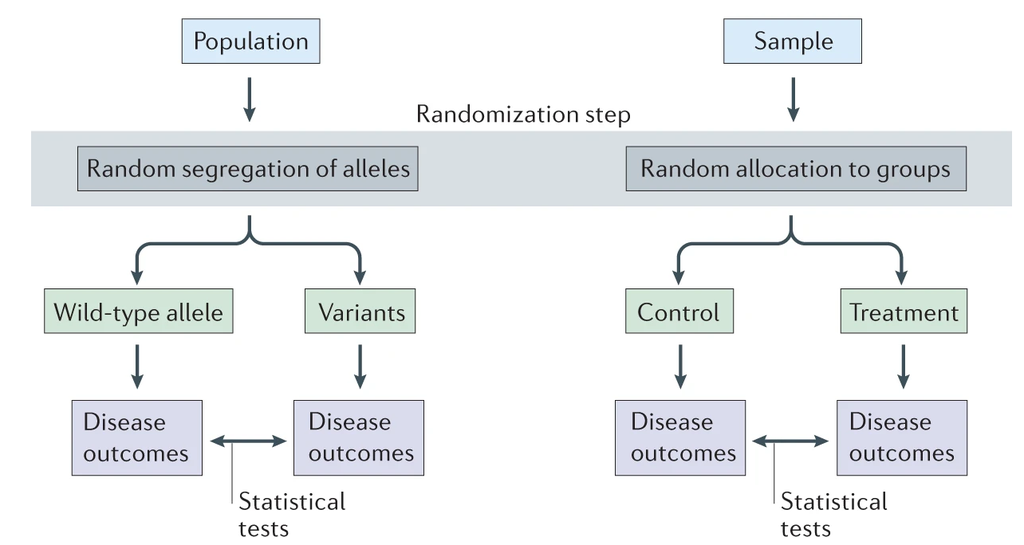

MR study design, Sanderson et al., 2022, *Nature reviews methods primers*

## Mendelian Randomization

To do this, we can use Mendelian Randomization (MR), which leverages genetic variants as instrumental variables (IVs) to estimate the causal effect of an exposure ($\color{darkgreen}{X}$) on an outcome ($\color{darkorange}{Y}$).

*In the case of no confounding between $\color{darkgreen}{X}$ and $\color{darkorange}{Y}$:*

$\color{darkgreen}{X_i} = \mu_x + G_i\beta + \epsilon_{x_i}$  
$\color{darkorange}{Y_i} = \mu_y + \color{darkgreen}{X_i}\color{darkblue}{\alpha} + \epsilon_{y_i}$

Assuming $E(\epsilon_{x}) = E(\epsilon_{y}) = 0$ and $Cov(\epsilon_{x}, \epsilon_{y}) = 0$. $G_i$ are genotypes for the $ith$ individual.

## Implications of this two stage model: Expectation

$$\begin{align}
E(\color{darkorange}{Y_i} | G_i) &= E\bigl(E(\color{darkorange}{Y_i} | \color{darkgreen}{X_i}, G_i)\bigr) \\
&= \mu_y + \color{darkblue}{\alpha}E(\color{darkgreen}{X_i | G_i}) \\
&= \mu_y + \color{darkblue}{\alpha}(G_i\beta + \mu_x)
\end{align}$$

## Implications of this two stage model: Covariance

$$\begin{align}
Cov(\color{darkorange}{Y}, \color{darkgreen}{X} \mid G) &= Cov(\mu_y + \color{darkblue}{\alpha}*\color{darkgreen}{X} + \epsilon_y,\ \color{darkgreen}{X} \mid G) \\
&= \color{darkblue}{\alpha} * Var(\color{darkgreen}{X} \mid G)
\end{align}$$

$$\begin{align}
Cov(\color{darkorange}{Y}, \color{darkgreen}{X}) &= E\bigl(Cov(\color{darkorange}{Y}, \color{darkgreen}{X} \mid G)\bigr) + Cov\bigl(E(\color{darkorange}{Y} \mid G), E(\color{darkgreen}{X} \mid G)\bigr) \\
&= \color{darkblue}{\alpha} * E\bigl(Var(\color{darkgreen}{X} \mid G)\bigr) + \color{darkblue}{\alpha} * Cov\bigl(E(\color{darkgreen}{X} \mid G), E(\color{darkgreen}{X} \mid G)\bigr) \\
&= \color{darkblue}{\alpha} * Var(\epsilon_x) + \color{darkblue}{\alpha} * \beta^2 Var(G)
\end{align}$$

Note: Only true if $Cov(\epsilon_y, \color{darkgreen}{X}) = 0$ !

## Now, a bit more realistic, with a confounder

*However, if there was no confounding between $\color{darkgreen}{X}$ and $\color{darkorange}{Y}$, why do we need MR anyway?*

## Now, a bit more realistic, with a confounder

Consider the following scenario where there is a confounder $U$ that affects both $\color{darkgreen}{X}$ and $\color{darkorange}{Y}$:

$$\begin{align}
\color{darkgreen}{X_i} &= \mu_x + G_i\beta + U_i\gamma + \epsilon_{x_i} \\
\color{darkorange}{Y_i} &= \mu_y + \color{darkgreen}{X_i}\color{darkblue}{\alpha} + U_i\delta + \epsilon_{y_i}
\end{align}$$

Here, $U_i$ represents the confounder, $\gamma$ is the effect of the confounder on $\color{darkgreen}{X}$, and $\delta$ is the effect of the confounder on $\color{darkorange}{Y}$.

## Implications of this model with a confounder

The presence of the confounder $U$ introduces bias in the estimation of the causal effect $\color{darkblue}{\alpha}$.

### Covariance

$$\begin{align}
Cov(\color{darkorange}{Y}, \color{darkgreen}{X} \mid G) &= Cov(\mu_y + \color{darkblue}{\alpha}\color{darkgreen}{X} + U\delta + \epsilon_y,\ \color{darkgreen}{X} \mid G) \\
&= \color{darkblue}{\alpha} * Var(\color{darkgreen}{X} \mid G) + \delta * Cov(U, \color{darkgreen}{X} \mid G)
\end{align}$$

Note: The term $\delta * Cov(U, \color{darkgreen}{X} \mid G)$ introduces bias due to the confounder $U$.

## Addressing confounding in MR

To address confounding, we can use genetic variants as instrumental variables (IVs) that are not associated with the confounder $U$. This allows us to estimate the causal effect $\color{darkblue}{\alpha}$ without bias from $U$.

## Example

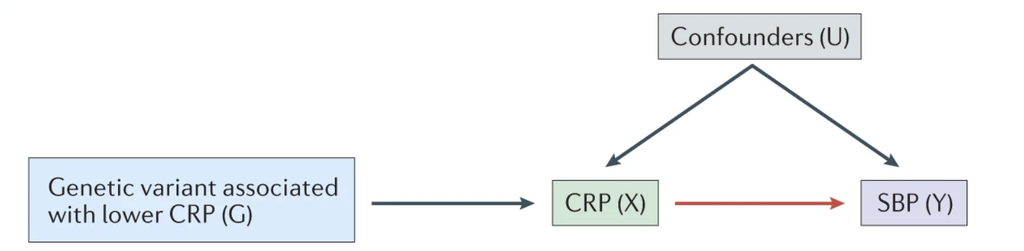

Sanderson et al., 2022, *Nature reviews methods primers*

## Example confounders

- Age
- Smoking
- Diet
- Alcohol consumption
- Comorbid diseases
- Many others…

## Assumptions of MR

1. Relevance: ($G$ is associated with $\color{darkgreen}{X}$)
2. Independence: ($G$ is not associated with $U$)
3. Exclusion restriction: The total effect of $G$ on $\color{darkorange}{Y}$ is mediated through $\color{darkgreen}{X}$

## How to estimate $\alpha$

Consider the least squares estimate of the effect of $X$ on $Y$

$$\color{darkblue}{\hat{\alpha}} = (\color{darkgreen}{X}^t\color{darkgreen}{X})^{-1} \color{darkgreen}{X}^t \color{darkorange}{Y}$$

What if we didn’t use the observed $\color{darkgreen}{X}$, but a proxy for it using $G$ ?

## Estimation

$$\hat{\beta} = (G^tG)^{-1}G^{t}\color{darkgreen}{X} \\
\color{darkgreen}{\hat{X}} = G(G^tG)^{-1}G^t\color{darkgreen}{X}$$

We can estimate $\color{darkblue}{\alpha}$ by plugging in our estimate of $\color{darkgreen}{X}$

$$\begin{align}
\color{darkblue}{\hat{\alpha}} &= \bigl((G(G^tG)^{-1}G^t\color{darkgreen}{X})^t(G(G^tG)^{-1}G^t\color{darkgreen}{X})\bigr)^{-1}(G(G^tG)^{-1}G^t\color{darkgreen}{X})^t\color{darkorange}{Y} \\
P_G &= G(G^tG)^{-1}G \\
\color{darkblue}{\hat{\alpha}} &= \bigl( (P_G \color{darkgreen}{X})^t(P_G \color{darkgreen}{X}) \bigr)^{-1} (P_G \color{darkgreen}{X})^t \color{darkorange}{Y} \\
\color{darkblue}{\hat{\alpha}} &= \bigl( \color{darkgreen}{X}^t P_G \color{darkgreen}{X} \bigr)^{-1} \color{darkgreen}{X}^t P_G \color{darkorange}{Y}
\end{align}$$

## Estimation

$$E\bigl(( \color{darkgreen}{X}^t P_G \color{darkgreen}{X} )^{-1} \color{darkgreen}{X}^t P_G \color{darkorange}{Y} \bigr) \\$$

$$\begin{align*}
&= E\bigl(E\bigl(( \color{darkgreen}{X}^t P_G \color{darkgreen}{X} )^{-1} \color{darkgreen}{X}^t P_G \color{darkorange}{Y} \mid \color{darkgreen}{X} \bigr) \bigr) \\
&= E\bigl(( \color{darkgreen}{X}^t P_G \color{darkgreen}{X} )^{-1} ( \color{darkgreen}{X}^t P_G \color{darkgreen}{X}) \color{darkblue}{\alpha} + ( \color{darkgreen}{X}^t P_G \color{darkgreen}{X})^{-1} E(\epsilon_y | \color{darkgreen}{X}) \bigr) \\
&= \color{darkblue}{\alpha} * I + E\bigl(( \color{darkgreen}{X}^t P_G \color{darkgreen}{X})^{-1} E(\epsilon_y | \color{darkgreen}{X}) \bigr)\\
&= \color{darkblue}{\alpha} \quad\quad \text{if A1}
\end{align*}$$

$A1$: $E(\color{darkorange}{Y}|\color{darkgreen}{X}, G) = \color{darkblue}{\alpha} \color{darkgreen}{X}$

*In general A1 is not true in finite samples*

## The asymptotic bias

To understand the asymptotic bias of the IV estimator, consider the bias:

$$E\bigl(( \color{darkgreen}{X}^t P_G \color{darkgreen}{X})^{-1} \color{darkgreen}{X^t}P_G\epsilon_y \bigr)$$

- Expectation is difficult to evaluate, because we can’t move the expectation operator in the inverse (a non-linear function)
- However, we can approximate this with some asymptotic arguments.

$$\frac{1}{n}\color{darkgreen}{X^t}P_G\color{darkgreen}{X} \rightarrow Q_{XG}$$

$$\frac{1}{n}\color{darkgreen}{X^t}P_G\epsilon_y \rightarrow 0 \quad \text{by assumption}$$

Then:
$$E\bigl(( \color{darkgreen}{X}^t P_G \color{darkgreen}{X})^{-1} \color{darkgreen}{X^t}P_G\epsilon_y \bigr) \rightarrow Q^{-1}_{XG} * 0 = 0$$

This is an estimator of $\color{darkblue}{\alpha}$ if one has access to $G$, $\color{darkgreen}{X}$, and $\color{darkorange}{Y}$ all at the same time. *Often, however, this is not the case*.

## Two-sample MR

It’s quite natural in MR to ask whether some molecular phenotype mediates the assocation between genotype and phenotype

- Does gene expression mediate the association between $G$ and $\color{darkorange}{Y}$? (e.g., TWAS)
- Does protein abundance mediate the association? (e.g. PWAS)
- Do metabolites mediate the association?

Often, interesting molecular phenotypes are measured in distinct cohorts (e.g., GTEx, Geuvadis) from the GWAS.

## Inverse-variance weighted estimator (IVW)

Assume that summary statistics for the following have been generated:

- Association between $G$ and $\color{darkgreen}{X}$ : $\hat{\beta}$, $\hat{\sigma^2_x}$,
- Association between $G$ and $\color{darkorange}{Y}$ : $\hat{\psi}$, $\hat{\sigma^2_y}$

$$\begin{aligned}
\hat{\alpha}_{IVW} &= \frac{\sum_{i=1}^{P} W_i \frac{\hat{\psi}_i}{\hat{\beta}_i}}{\sum_{i=1}^{P} W_i}
\qquad\text{with}\qquad
W_i = \left(\frac{\hat{\beta}}{\hat{\sigma_y}}\right)^2
\end{aligned}$$

How would you estimate this the `lm` command in R?

## What if some of our instruments are invalid?

1. Perhaps some of the SNPs don’t predict the phenotype
2. Perhaps some of the SNPs have direct effects on the outcome phenotype

## Examining this behavior through simulation

```r
run_sim = function() {
  N = 1000
  P = 1
  beta = rep(0.5, P)
  alpha = 0.5
  U_sd = 0.3
  G = rnorm(N * P, mean = 0, sd = 1)
  U = rnorm(N, mean = 0, sd = U_sd)
  X = G * beta + rnorm(N, mean = 0, sd = sqrt(1.0 - beta ^ 2 - U_sd ^ 2)) + U
  Y = X * alpha + rnorm(N, mean = 0, sd = sqrt(1.0 - alpha ^ 2 * var(X) - U_sd ^ 2)) + U
  return(coef(lm(Y ~ X))[2])
}

sims = map_dbl(1:1000, ~run_sim())
```

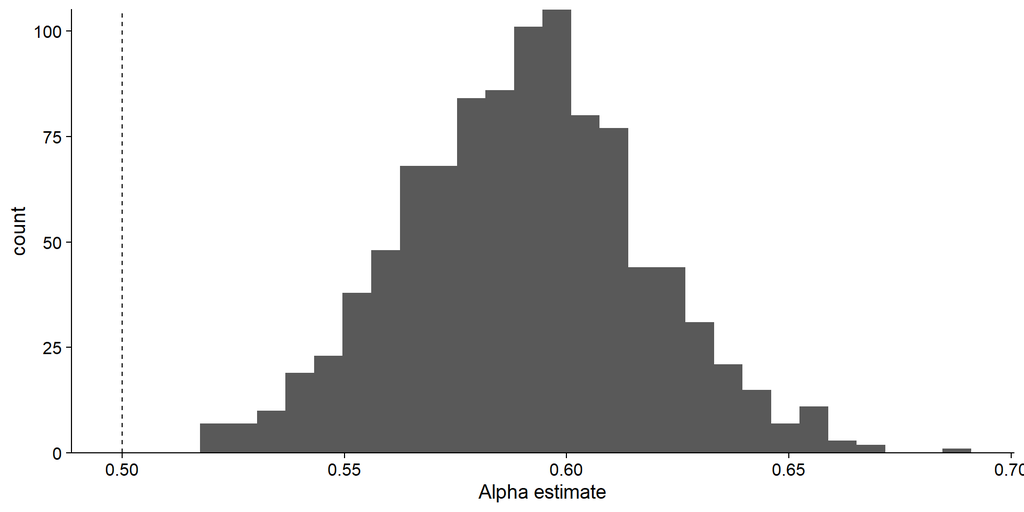

## Now, with instrumental variables

```r
run_sim_iv = function() {
  N = 1000
  P = 1
  beta = 0.5
  alpha = 0.5
  U_sd = 0.3
  G = rnorm(N * P, mean = 0, sd = 1)
  U = rnorm(N, mean = 0, sd = U_sd)
  X = G * beta + rnorm(N, mean = 0, sd = sqrt(1.0 - beta ^ 2 - U_sd ^ 2)) + U
  Y = X * alpha + rnorm(N, mean = 0, sd = sqrt(1.0 - alpha ^ 2 * var(X) - U_sd ^ 2)) + U


  YG = coef(lm(Y ~ G))[2]
  XG = coef(lm(X ~ G))[2]
  return(YG / XG)
}

sims_iv = map_dbl(1:1000, ~run_sim_iv())
```

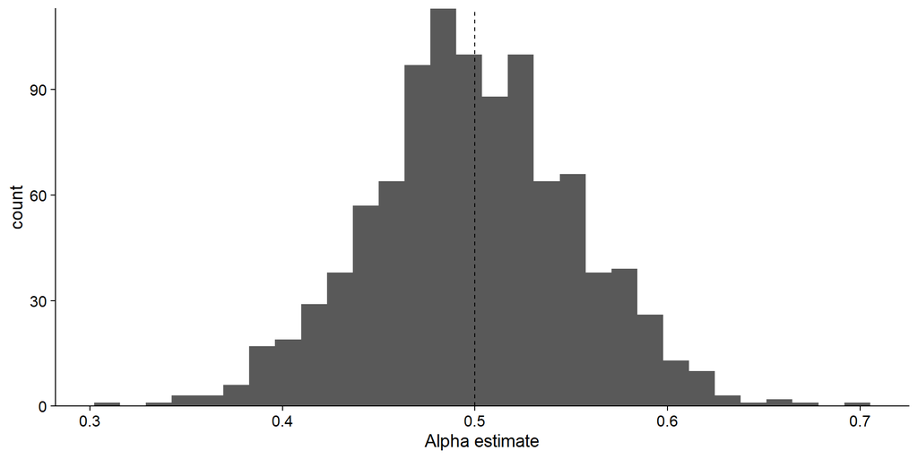

## Weak instrument simulation

```r
run_sim_iv_weak = function() {
  N = 1000
  P = 1
  beta = 0.03
  alpha = 0.5
  U_sd = 0.3
  G = rnorm(N * P, mean = 0, sd = 1)
  U = rnorm(N, mean = 0, sd = U_sd)
  X = G * beta + rnorm(N, mean = 0, sd = sqrt(1.0 - beta ^ 2 - U_sd ^ 2)) + U
  Y = X * alpha + rnorm(N, mean = 0, sd = sqrt(1.0 - alpha ^ 2 * var(X) - U_sd ^ 2)) + U


  YG = coef(lm(Y ~ G))[2]
  XG = coef(lm(X ~ G))[2]
  return(YG / XG)
}

set.seed(3)
sims_iv_weak = map_dbl(1:1000, ~run_sim_iv_weak())
```

## Bias when instruments are weak

```r
sprintf("mean: %f", mean(sims_iv_weak))
```

```
[1] "mean: 0.296619"
```

```r
sprintf("se: %f", sd(sims_iv_weak) / sqrt(1000))
```

```
[1] "se: 0.350748"
```

## MR-RAPS

Consider the likelihood

$$\mathcal{l}(\color{darkblue}{\alpha}, \beta_1, \ldots, \beta_P) = -0.5 \left[ \sum_{i=1}^{P} \frac{(\hat{\beta}_i - \beta_i)^2}{\sigma^2_{x_i}} + \sum_{i=1}^{P} \frac{(\hat{\psi}_i - \beta_i\, \color{darkblue}{\alpha})^2}{\sigma^2_{y_i}} \right]$$

After profiling out the $\beta$ terms:

$$\mathcal{l}(\color{darkblue}{\alpha}) = -0.5 \sum_{i=1}^{P}\frac{(\hat{\psi}_i - \color{darkblue}{\alpha}\,\hat{\beta}_i)^2}{\sigma^2_{X_i}\color{darkblue}{\alpha}^2 + \sigma^2_{Y_i}}$$

Zhao et al., 2020, *Annals of Statistics*.

## Robust likelihood

$$\mathcal{l}(\color{darkblue}{\alpha}) = -0.5 \sum_{i=1}^{P}\frac{\rho\Bigl(\hat{\psi}_i - \color{darkblue}{\alpha}\,\hat{\beta}_i\Bigr)}{\sqrt{\sigma^2_{X_i}\,\color{darkblue}{\alpha}^2 + \sigma^2_{Y_i}}}$$

with $\rho$ defined as some “robust” loss function, e.g., the Huber loss:

$$\rho(r; k) = \begin{cases}
\frac{1}{2}r^2, & \text{if } |r| \le k,\\[1ex]
k\,|r| - \frac{1}{2}k^2, & \text{if } |r| > k.
\end{cases}$$

## Returning to pleiotropy

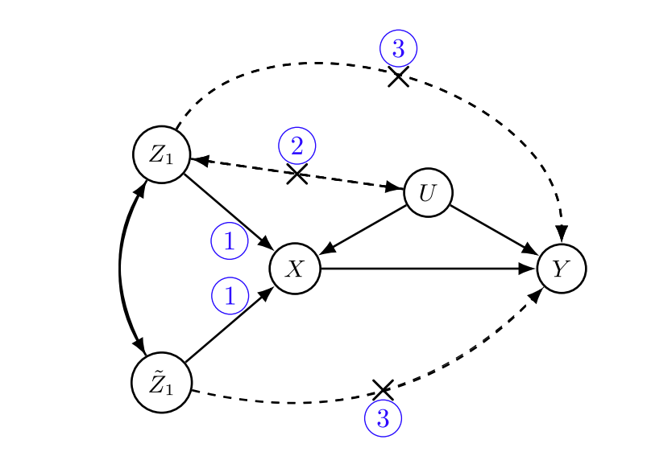

Zhao et al., 2020, *AOS*

## Complex traits are highly pleiotropic

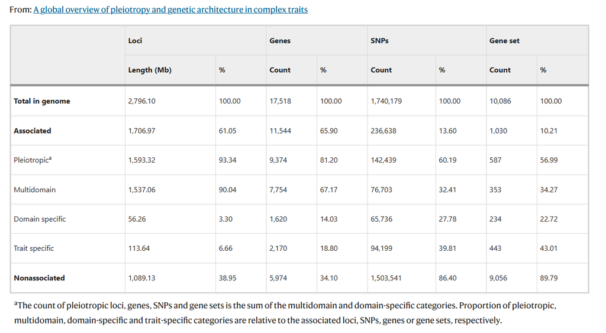

Table 1, Watanabe et al., *Nature Genetics*, 2019

## Complex traits are highly polygenic

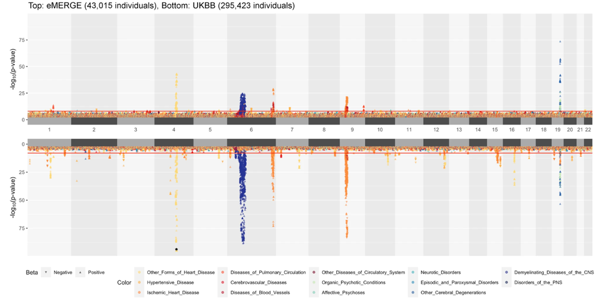

Figure 1, Zhang et al., *Nature Communications*, 2022

## Correlated and Uncorrelated pleiotropy

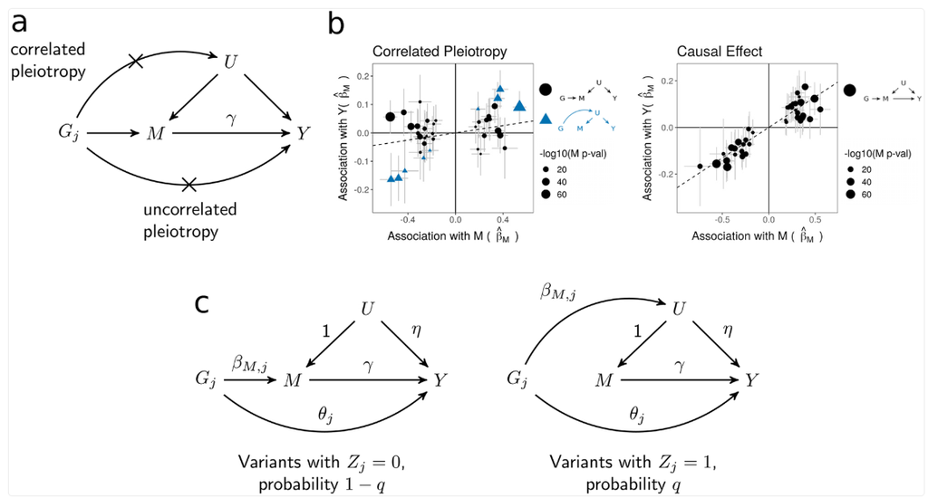

Figure 1, Morrison et al., *Nature Genetics*, 2020

## MR-CAUSE

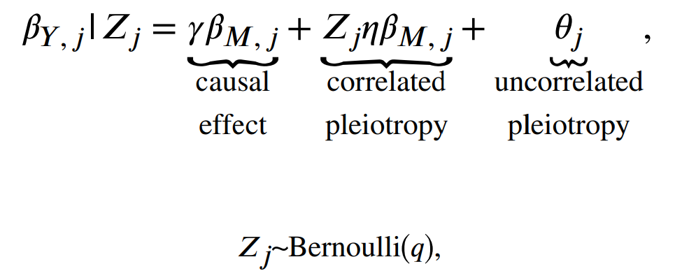

Methods, Morrison et al., *Nature Genetics*, 2020

## Pleiotropy in MR-RAPS

Assume: $\psi - \alpha * \beta \sim N(0, \tau^2)$

Then:

$$\mathcal{l}(\alpha) = -0.5 * \sum_{i=1}^{P}\frac{(\hat{\psi}_i - \alpha \hat{\beta})^2}{\sigma^2_{X_i}\alpha^2 + \sigma^2_{Y_i} + \color{red}{\hat{\tau}^2}}$$

## Sparsity assumptions on uncorrelated pleiotropy terms

[figure not shown]

Berzuini et al., 2020, *Biostatistics*

## Bayesian inference of pleiotropy terms

Consider the following structural equation models:
$$\begin{align}
\color{darkgreen}{X_i} &= \mu_x + G_i\beta + U_i\gamma + \epsilon_{x_i} \\
\color{darkorange}{Y_i} &= \mu_y + \color{darkgreen}{X_i}\color{darkblue}{\alpha} + U_i\delta +
\color{red}{G_{i} \theta} +
\epsilon_{y_i}
\end{align}$$

What probabilistic assumptions can we place on $\theta$ to make these terms identifiable?

## Sparse prior on $\theta$

$$\theta_j \sim \mathcal{N}(0, \lambda_j^2 \tau^2) \\
\lambda_j \sim \mathcal{C}^{+}(0, 1) \\
\tau \sim \mathcal{C}^{+}(0, 1)$$

## What is this doing?

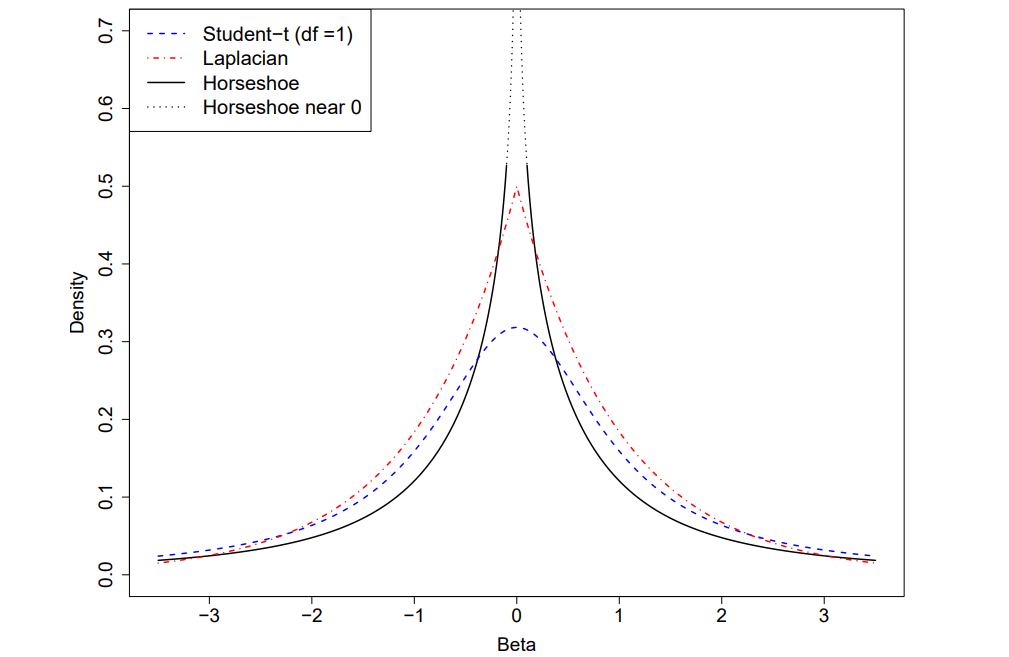

Carvalho et al., 2009, *JMLR*

Posterior computation performed with Hamiltonian Monte-Carlo implemented in the Stan probabilistic programming language.

## MR-PRESSO

[figure not shown]

Verbanck et al., 2018, *Nature Genetics*

## MR-PRESSO

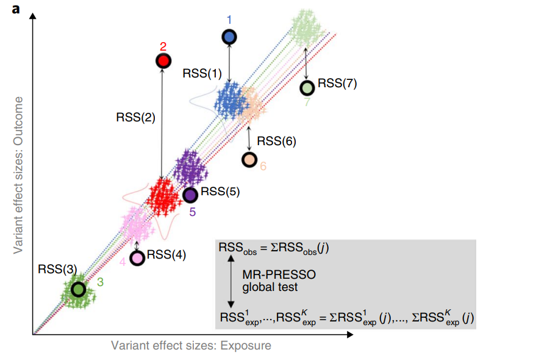

Figure 1a, Verbanck et al.

## MR-PRESSO

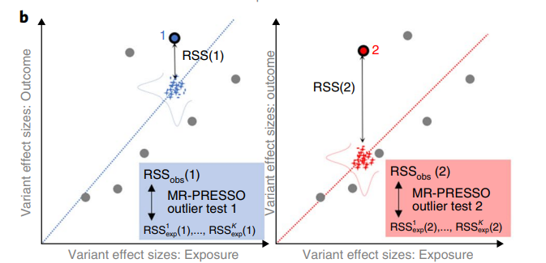

Figure 1b, Verbanck et al.

## MR-PRESSO

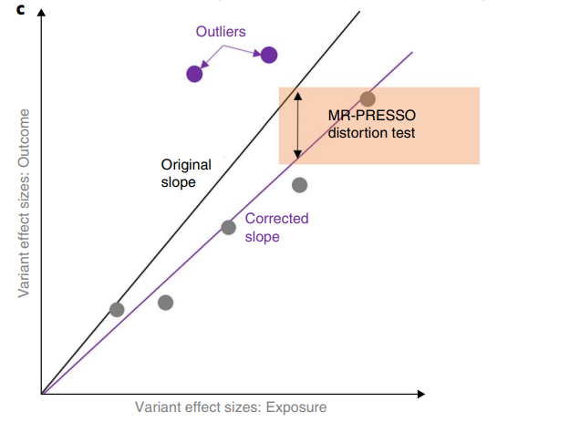

Figure 1c, Verbanck et al.

## Network MR: bidirectional MR on many phenotypes

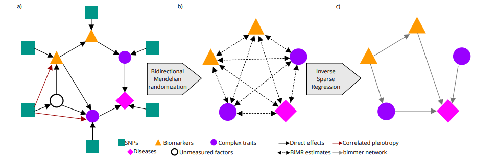

Brown and Knowles, 2020, biorxiv

1. Estimate all pairwise total effects between all possible $\color{darkgreen}{X}$ and $\color{darkorange}{Y}$
2. Define all total effects as the matrix $\mathcal{T}$
3. Estimate a sparse inverse $\mathcal{G}=\mathcal{T}^{-1}$, which estimates direct effects

## MR “in action”

[figure not shown]

Voight et al., 2012, *The Lancet*

- Single SNP MR to assess $HDL \rightarrow MI$
- Missense variant in *LIPG*, reported to affect HDL but not other lipids
- Examine association between this SNP with $MI$ in many cohorts

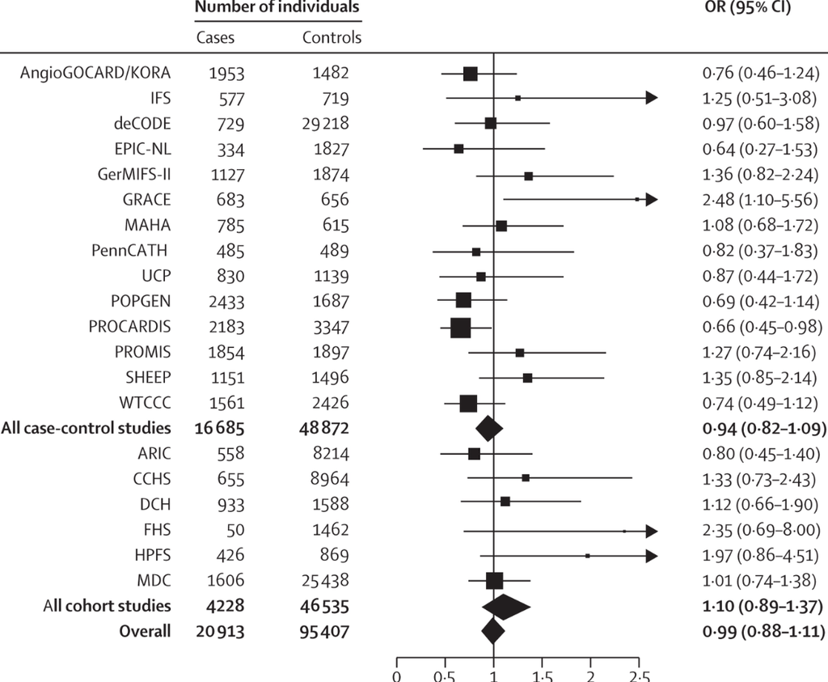

Figure 2, Voight et al.

## MR literature crisis

[figure not shown]

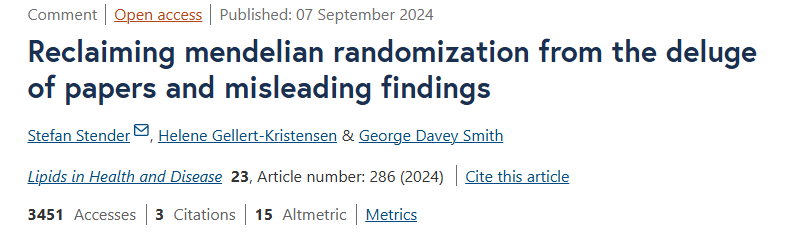

## MR literature crisis

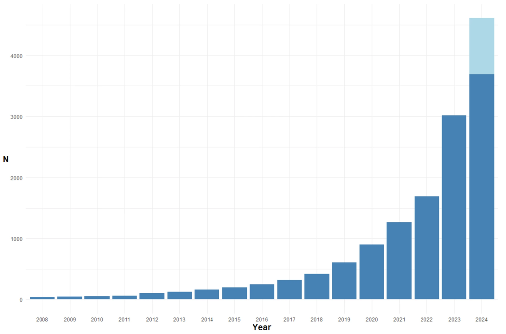

Stender et al., *Lipids in Health and Disease*, 2024

## Call to editors:

*“First, the public availability of summary results from genome-wide association studies has led to an *explosion of low-quality two-sample mendelian randomization (2SMR)* studies. These studies add minimal – if any – value and overwhelm reviewers and journals. Second, the availability of large datasets with individual-level genotype data, like UK Biobank, has spurred the development and use of novel MR methods. However, some methods are being applied without proper testing, leading to misleading results, as exemplified by recent spurious findings that are being retracted and/or corrected relating to vitamin D. What can editors and peer reviewers do to handle the deluge of 2SMR studies and the premature application of highly complex MR methods? *We advise editors to simply reject papers that only report 2SMR findings*, with no additional supporting evidence.”*

Stender et al., *Lipids in Health and Disease*, 2024

## In summary

- MR is an IV approach for estimating the causal effect of $\color{darkgreen}{X}$ on $\color{darkorange}{Y}$
- Challenges include
  1. weak instruments
  2. extensive pleiotropy (both correlated and uncorrelated)
  3. how to model several phenotypes
- The “convenience” of 2SMR studies has led to a deluge of weak papers